# CMP713 Data Mining

## 2024-2025 Spring - Assigment 2

## Given 12/05/2025, Due 21/05/2025 (excluded)

| Name | ID | Points | Task1 | Task2 | Task3 | Total |
| --- | --- | --- | --- | --- | --- | --- |
| Gizem Aleyna Tuzcu | N24120196 | Max | 15 | 10 | 10 | 35 |
|  |  | Given | 0 | 0 | 0 | 0 |

In this assignment you will work on a synthetic dataset related to the fictional *Zoomba* fruit. Note that the zoomba fruit is completely fictional and does not exist in reality.

Do not change anything in this document, other than `student_name` and `student_id` variables in the above chunk, and the Answer sections below. In this assignment, you will submit your Rmd file at the end. Your solution should assume that the raw data is imported from `zoomba_train.csv` file in the same folder as your Rmd file.

Your solution should never install new packages! Only the packages we have shown in the course are allowed, and these are already installed on my computer. So, do not try to reinstall them (please!).

Good luck!

### TASK 1

Import the data into R. Employ a brief exploratory data analysis to understand and preprocess the data. Draw plots when necessary but don’t overdo it!

You are expected to

- Understand feature distributions
- Handle NAs (if any)
- Deal with anomalies (if any)

#### Explanation

First, NA values are read from csv file, they were written to file as “???”. “sweetness_level” feature has 294NA values and filled with “mean value” of the feature. After that, categorical features encoded so that the model can handle the data. And lastly, outliers are removed from the dataset and instead filled with mean values.

#### Answer

```r
library(ggplot2)
library(dplyr)
library(e1071)
library(rpart)
library(cluster)

zoomba_data <- read.csv("zoomba_train.csv", na.strings = "???")
zoomba_data <- zoomba_data %>% select(-fruit_id)

str(zoomba_data)
```

```
## 'data.frame':    1000 obs. of  12 variables:
##  $ species           : chr  "Fati" "Sferi" "Fati" "Sferi" ...
##  $ length_cm         : num  5.64 7.74 6.41 6.57 6.23 7.23 7.96 8.93 7.45 6.79 ...
##  $ radius_cm         : num  5.76 4.28 5.31 3.6 4.6 3.36 2.41 2.41 2.75 3 ...
##  $ weight_g          : num  163 94 139 89 130 ...
##  $ seed_count        : int  3 3 3 3 3 5 4 3 5 5 ...
##  $ ripeness          : chr  "Ripe" "Ripe" "Overripe" "Ripe" ...
##  $ sweetness_level   : num  2.8 6.6 9 5.8 6.9 4.2 5.2 NA 2.2 7 ...
##  $ origin            : chr  "Uganda" "Kenya" "Kenya" "Chad" ...
##  $ acidity_level     : num  1.82 2.96 2.83 3.78 1.84 2.95 1.81 6.3 1.84 3.77 ...
##  $ skin_thickness    : num  0.48 0.12 0.49 0.08 0.54 0.1 0.15 0.17 0.17 0.09 ...
##  $ days_since_harvest: int  23 14 28 11 3 16 8 11 9 17 ...
##  $ price             : num  3 7 5.5 7 6 5 7 4.5 5 6.5 ...
```

```r
summary(zoomba_data)
```

```
##    species            length_cm        radius_cm        weight_g
##  Length:1000        Min.   : 4.480   Min.   :1.740   Min.   : 76.1
##  Class :character   1st Qu.: 6.180   1st Qu.:2.850   1st Qu.:103.1
##  Mode  :character   Median : 6.870   Median :3.550   Median :118.3
##                     Mean   : 7.189   Mean   :3.578   Mean   :119.7
##                     3rd Qu.: 8.012   3rd Qu.:4.220   3rd Qu.:133.7
##                     Max.   :12.120   Max.   :6.040   Max.   :184.5
##
##    seed_count      ripeness         sweetness_level    origin
##  Min.   :3.000   Length:1000        Min.   :1.000   Length:1000
##  1st Qu.:3.000   Class :character   1st Qu.:3.900   Class :character
##  Median :4.000   Mode  :character   Median :5.500   Mode  :character
##  Mean   :3.846                      Mean   :5.289
##  3rd Qu.:5.000                      3rd Qu.:6.900
##  Max.   :5.000                      Max.   :9.000
##                                     NA's   :294
##  acidity_level   skin_thickness   days_since_harvest     price
##  Min.   :1.570   Min.   :0.0400   Min.   : 1.00      Min.   :1.500
##  1st Qu.:2.040   1st Qu.:0.1100   1st Qu.: 8.00      1st Qu.:4.500
##  Median :2.950   Median :0.2000   Median :15.00      Median :5.500
##  Mean   :3.303   Mean   :0.2673   Mean   :15.28      Mean   :5.371
##  3rd Qu.:4.112   3rd Qu.:0.4700   3rd Qu.:23.00      3rd Qu.:6.000
##  Max.   :6.760   Max.   :0.6200   Max.   :30.00      Max.   :7.500
##
```

```r
head(zoomba_data)
```

```
##   species length_cm radius_cm weight_g seed_count ripeness sweetness_level
## 1    Fati      5.64      5.76    162.8          3     Ripe             2.8
## 2   Sferi      7.74      4.28     94.0          3     Ripe             6.6
## 3    Fati      6.41      5.31    139.2          3 Overripe             9.0
## 4   Sferi      6.57      3.60     89.0          3     Ripe             5.8
## 5    Fati      6.23      4.60    129.7          3     Ripe             6.9
## 6   Sferi      7.23      3.36    116.8          5     Ripe             4.2
##   origin acidity_level skin_thickness days_since_harvest price
## 1 Uganda          1.82           0.48                 23   3.0
## 2  Kenya          2.96           0.12                 14   7.0
## 3  Kenya          2.83           0.49                 28   5.5
## 4   Chad          3.78           0.08                 11   7.0
## 5 Uganda          1.84           0.54                  3   6.0
## 6  Kenya          2.95           0.10                 16   5.0
```

```r
colSums(is.na(zoomba_data))
```

```
##            species          length_cm          radius_cm           weight_g
##                  0                  0                  0                  0
##         seed_count           ripeness    sweetness_level             origin
##                  0                  0                294                  0
##      acidity_level     skin_thickness days_since_harvest              price
##                  0                  0                  0                  0
```

```r
# 294 NA values exist in sweetness

# NA values filled with mean value of rest
zoomba_data$sweetness_level[is.na(zoomba_data$sweetness_level)]<-mean(zoomba_data$sweetness_level,na.rm=TRUE)

colSums(is.na(zoomba_data))
```

```
##            species          length_cm          radius_cm           weight_g
##                  0                  0                  0                  0
##         seed_count           ripeness    sweetness_level             origin
##                  0                  0                  0                  0
##      acidity_level     skin_thickness days_since_harvest              price
##                  0                  0                  0                  0
```

```r
numeric_features <- sapply(zoomba_data, is.numeric)
numeric_features
```

```
##            species          length_cm          radius_cm           weight_g
##              FALSE               TRUE               TRUE               TRUE
##         seed_count           ripeness    sweetness_level             origin
##               TRUE              FALSE               TRUE              FALSE
##      acidity_level     skin_thickness days_since_harvest              price
##               TRUE               TRUE               TRUE               TRUE
```

```r
#converting categorical value to numeric

categorical_featues <- sapply(zoomba_data, is.character)
categorical_featues
```

```
##            species          length_cm          radius_cm           weight_g
##               TRUE              FALSE              FALSE              FALSE
##         seed_count           ripeness    sweetness_level             origin
##              FALSE               TRUE              FALSE               TRUE
##      acidity_level     skin_thickness days_since_harvest              price
##              FALSE              FALSE              FALSE              FALSE
```

```r
for (col in names(zoomba_data)[categorical_featues]) {
  print(col)
  zoomba_data[[col]] <-  as.numeric(factor(zoomba_data[[col]]))
}
```

```
## [1] "species"
## [1] "ripeness"
## [1] "origin"
```

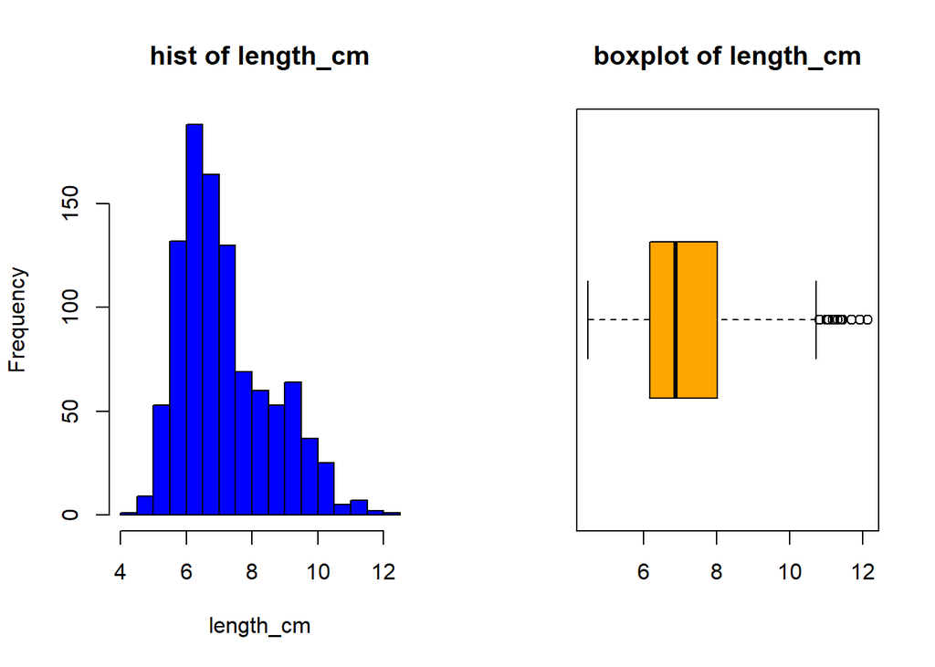

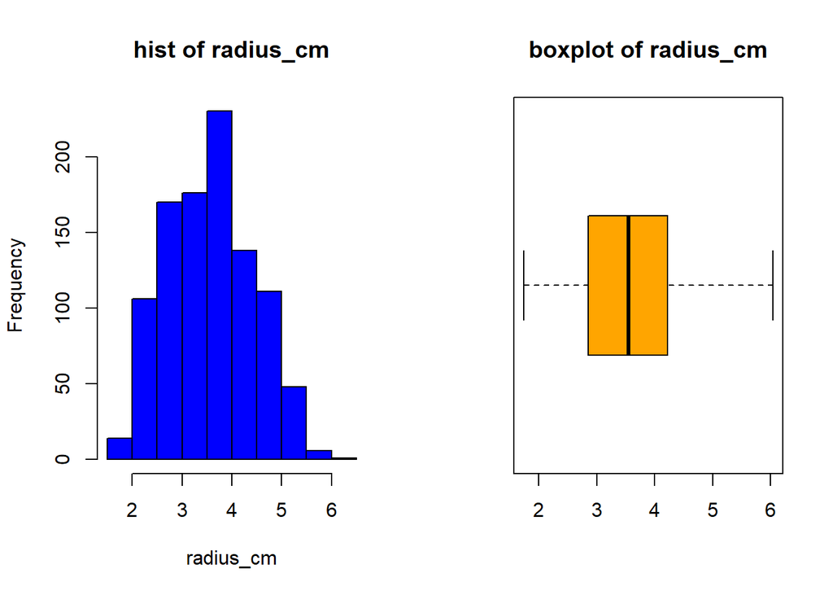

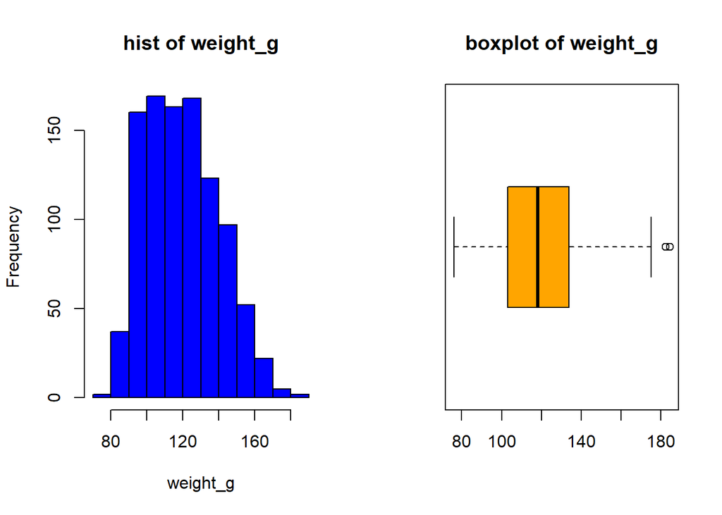

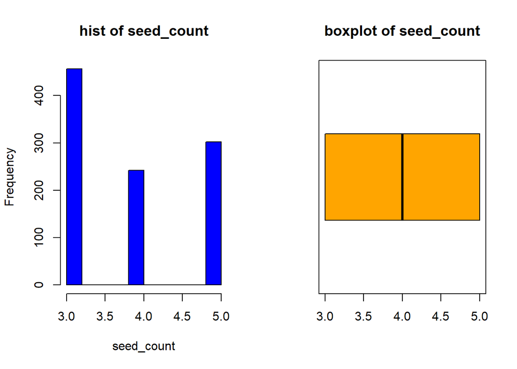

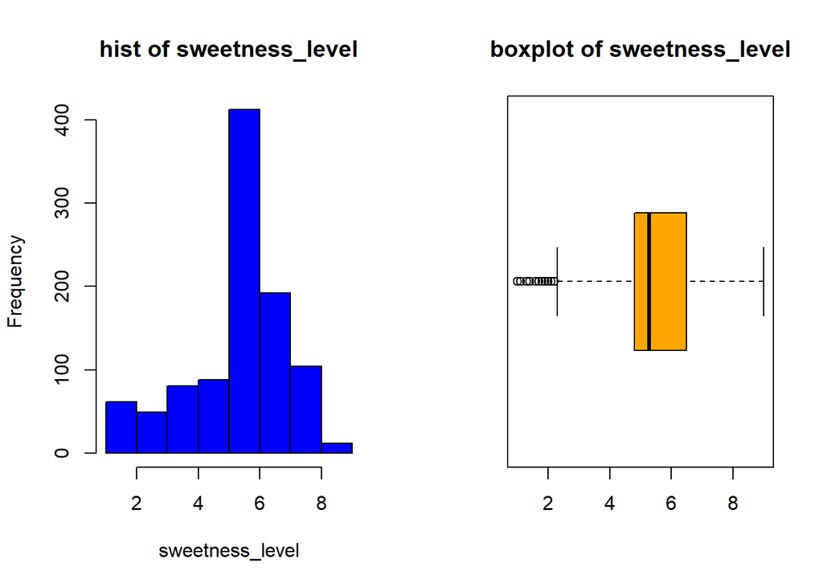

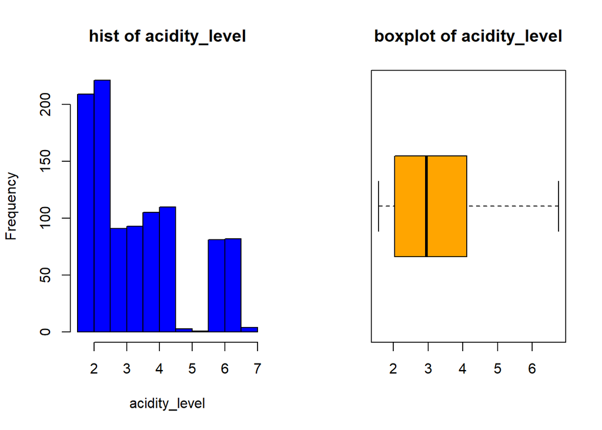

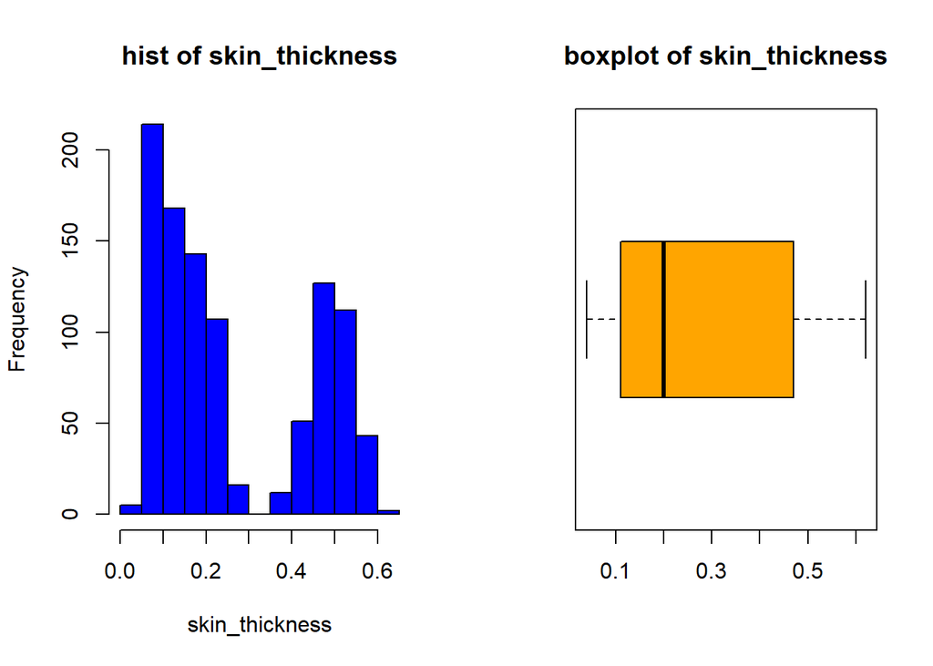

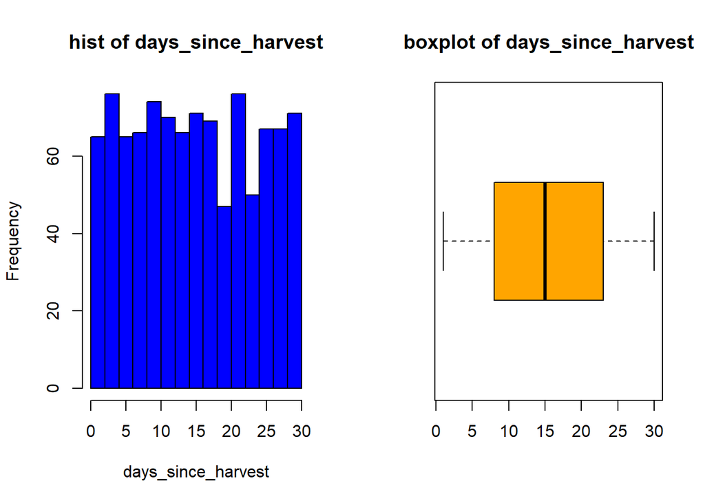

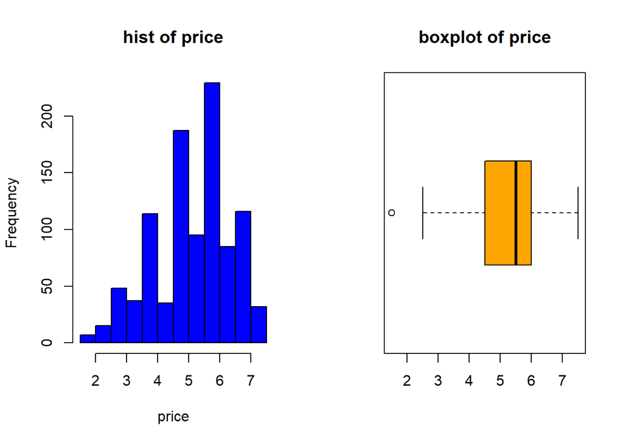

```r
par(mfrow = c(1, 2))
for (col in names(zoomba_data)[numeric_features]) {
  hist(zoomba_data[[col]],col = "blue", main = paste("hist of", col), xlab = col)
  boxplot(zoomba_data[[col]], main = paste("boxplot of", col),col = "orange",horizontal = TRUE)
}
```

```r
detect_outlier <- function(x) {
  Q1 <- quantile(x, 0.25, na.rm = TRUE)
  Q3 <- quantile(x, 0.75, na.rm = TRUE)
  IQR <- Q3 - Q1
  lower_bound <- Q1 -1.5 * IQR
  uper_bound <- Q3 +1.5 * IQR
  return(x < lower_bound | x > uper_bound)
}

cols_to_check = c("length_cm", "price", "weight_g")

for (col in cols_to_check) {
  outliers <- detect_outlier(zoomba_data[[col]])
  num_outliers <- sum(outliers, na.rm = TRUE)

  cat("\nColumn:", col, "\n")
  cat("Number of outliers:", num_outliers, "\n")

  if (num_outliers > 0) {
    mean_val <- mean(zoomba_data[[col]][!outliers], na.rm = TRUE)
    zoomba_data[[col]][outliers] <- mean_val
    cat("Outliers replaced with mean.\n")
  } else {
    cat("No outliers found.\n")
  }
}
```

```
##
## Column: length_cm
## Number of outliers: 12
## Outliers replaced with mean.
##
## Column: price
## Number of outliers: 7
## Outliers replaced with mean.
##
## Column: weight_g
## Number of outliers: 2
## Outliers replaced with mean.
```

### TASK 2

Develop a model to predict the price of a Zoomba fruit. You can use the models we learned in class but not anything else. You are allowed to employ clustering, dependency modelling, decision tree models or SVM. You are not allowed to use any models beyond that, such as random forest or ANN.

You must store your model as `my_model`, otherwise the next Task will fail and you will lose marks.

#### Explanation

A SVM model is developed and fine-tuned across different parameters such as cost, gamma and epsilon values. Best model has been choosen according to lowest RMSE value. Dataset is divided into train and validation parts for the model by 80-20 ratio.

#### Answer

```r
set.seed(456)

n <- nrow(zoomba_data)
train_index <- sample(1:n, size = 0.8 * n)

train_data <- zoomba_data[train_index, ]
val_data <- zoomba_data[-train_index, ]

cost_values <- c(0.1, 1, 10)
gamma_values <- c(0.1, 0.25, 0.5)
epsilon = c(0.01, 0.1, 0.2)

best_model <- NULL
lowest_rmse <- Inf

for (c in cost_values) {
  for (g in gamma_values) {
    for (e in epsilon) {
      model <- svm(price ~ ., data = train_data, type = "eps-regression", cost = c, gamma = g, epsilon= e)
      preds <- predict(model, val_data)
      rmse <- sqrt(mean((preds - val_data$price)^2))

      if (rmse < lowest_rmse) {
        lowest_rmse <- rmse
        best_model <- model
      }
    }

  }
}

my_model  <- best_model
```

### TASK 3

You are not allowed to write/change any code for this Task. This task will be executed by the instructor for automatic evaluation. You will **not** be given the `zoomba_test.csv` file at any times.

#### Note

Since encoding and NA value filling done previously, little adjustments done here too.

#### Answer

```r
if (FALSE)
{
  test_data <- read.csv("zoomba_test.csv", na.strings = "???")
  test_data <- test_data %>% select(-fruit_id)

  test_data$species         <- as.numeric(factor(test_data$species))
  test_data$ripeness        <- as.numeric(factor(test_data$ripeness))
  test_data$origin          <- as.numeric(factor(test_data$origin))

  test_data$sweetness_level[is.na(test_data$sweetness_level)] <- mean(
    test_data$sweetness_level, na.rm = TRUE
  )



  predictions <- predict(my_model, select(test_data, -price))

  mean(abs(test_data$price - predictions))
}
```